# Markdown

Alissa Tophinke, Dionis Anderegg

27 Mai 2021

# Packages

Erforderliche Packages laden:

```r
library(rgdal)
library(sf)
library(tidyverse)
library(lubridate)
library(zoo)

if(!requireNamespace("remotes")) {
    install.packages("remotes")
}
remotes::install_github("grimbough/FITfileR")

library(FITfileR)
library(gdata)
```

# Import

Alle Files mit Endung .fit aus dem R-Projektordner importieren und in ein einzelnes Data.frame zusammenführen. Alle anderen Data.frames löschen, sodass nur noch das gesamte DF im Workspace ist. Diverse Berechnungen müssen somit nur einmalig durchgeführt werden (timelag, Distanz usw.).

```r
test1 <- readFitFile("6020722827_ACTIVITY.fit")
test2<- records(readFitFile("6020722827_ACTIVITY.fit"))
test3<- as.data.frame(records(readFitFile("6020722827_ACTIVITY.fit")))
?records
```

```
## starting httpd help server ... done
```

```r
myfiles <- list.files(".",pattern = "*.fit")

for (i in 1:length(myfiles)) {
  varName <- paste0("temp", i, ".fit")
  assign(varName, as.data.frame(records(readFitFile(myfiles[i]))))
}

full <- mget(ls(pattern="temp")) %>%
              bind_rows()
keep(full, sure = TRUE)
head(full)
```

```
##             timestamp position_lat position_long distance enhanced_speed
## 1 2020-12-29 13:29:32     47.23942      9.175766     0.00          2.771
## 2 2020-12-29 13:29:33     47.23940      9.175735     2.81          2.417
## 3 2020-12-29 13:29:35     47.23938      9.175662     8.64          2.613
## 4 2020-12-29 13:29:38     47.23936      9.175579    15.49          2.566
## 5 2020-12-29 13:29:41     47.23933      9.175464    24.89          2.706
## 6 2020-12-29 13:29:43     47.23931      9.175401    29.93          2.650
##   enhanced_altitude heart_rate cadence fractional_cadence
## 1             758.0         89      83                  0
## 2             758.0         90      83                  0
## 3             759.6         93      82                  0
## 4             759.8         96      83                  0
## 5             759.8         99      82                  0
## 6             759.8        101      82                  0
```

# Nötige Variablen berechnen (noch nicht fertig, hier nur wenige).

Geschwindigkeit und Timelags berechnen. Aktivitäten müssen gruppiert werden können. Dies geschicht über die "activity_ID", welche das Data-Frame in einzelne Tracks segmentiert. Für die Distanz zwischen zwei GPS-Fixes muss ein SF-Objekt erstellt werden und in das Format CH1903+ LV95 umgewandelt werden. Daraus lässt sich die Distanz berechnen.

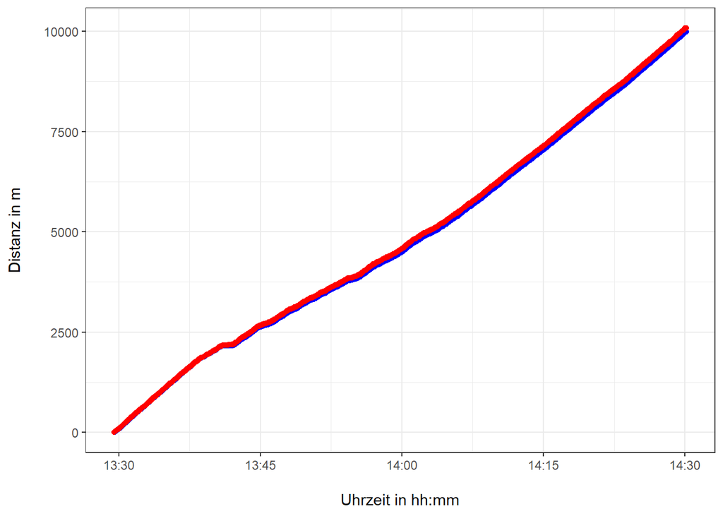

```r
# Geschwindigkeit in kmh
full$enhanced_speed_kmh <- full$enhanced_speed *3.6
# Timelag berechnen
full$timelag <- as.integer(difftime(full$timestamp, lag(full$timestamp)))
# Aktivitäts ID erstellen => Wichtig für Gruppieren etc.
full$activity_conter <- ifelse(full$timelag > 3600, TRUE, FALSE)   # Neue ID wenn mehr als 1 Stunde timelag
full$activity_conter[1] <- TRUE  # ID 1 = TRUE, da die dies die Aktivität nummer 1 ist

full$activity_ID <- cumsum(full$activity_conter == TRUE)  # Erstellt die AktivitätsID basierend auf Conter

# In SF umwandeln => Um die Euclidian distance zu berechnen
full_sf <- st_as_sf(full, coords = c("position_long", "position_lat"),
         crs = 4326)

# Konvertieren zu CH1903+ LV95
full_sf <- st_transform(full_sf, crs = 2056)
options(digits = 3)

# N und E Koordinaten aus der Geometrie ziehen
full_sf$N <- st_coordinates(full_sf$geometry)[,1]
full_sf$E <- st_coordinates(full_sf$geometry)[,2]

# Euclidian steplength berechnen

full_sf <- full_sf %>%
  group_by(activity_ID) %>%
  mutate(
    steplength = sqrt((E - lead(E))^2 + (N - lead(N))^2),
    steplenght_sum = cumsum(replace_na(steplength,0)),
    hightdiff = lead(enhanced_altitude) - enhanced_altitude,
    hightdiff_up = ifelse(hightdiff > 0, hightdiff, 0),
    hightdiff_down = ifelse(hightdiff < 0, hightdiff, 0)
  )

full_sf %>%
  filter(activity_ID == 1) %>%
  ggplot() +
  geom_point(aes(timestamp, distance), col = "blue") +
  geom_point(aes(timestamp, steplenght_sum), col = "red") +
  theme_bw() +
  labs(x = "\nUhrzeit in hh:mm", y = "Distanz in m\n")
```

```r
max(full_sf$distance) / max(full_sf$steplenght_sum)
```

```
## [1] 0.988
```

# Datenanalyse eines einzelnen Tracks

Folgend wird grafisch aufgezeigt, wie sich die Variablen Geschwindigkeit, Höhendifferenz und Herzfrequenz verhalten.

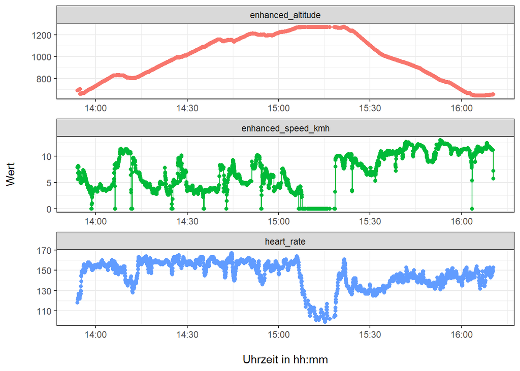

```r
full_long <- gather(full, type, value, enhanced_altitude:heart_rate, enhanced_speed_kmh)

full_long %>%
  filter(activity_ID == 5) %>%
  ggplot(aes(timestamp, value, col = type)) +
  geom_line()+
  geom_point() +
  facet_wrap(~type, scales = "free",ncol = 1) +
  theme_bw() +
  theme(legend.position = "none") +
  labs(x = "\nUhrzeit in hh:mm", y = "Wert\n")
```

In der Tendenz lässt sich visuell eine Abnahme der Geschwindigkeit und eine Zunahme der Herzfrequenz mit einem Höhenanstieg erkennen. Ausserdem ist eine Pause von ca. 10 minuten duetlich am Geschwindigkeitdiagramm zu erkennen.

# Visualisieren auf Karten

Tracks auf Karten darstellen (verschiedene Packages und Methoden). Welche Packages eignen sich?

ggplot:

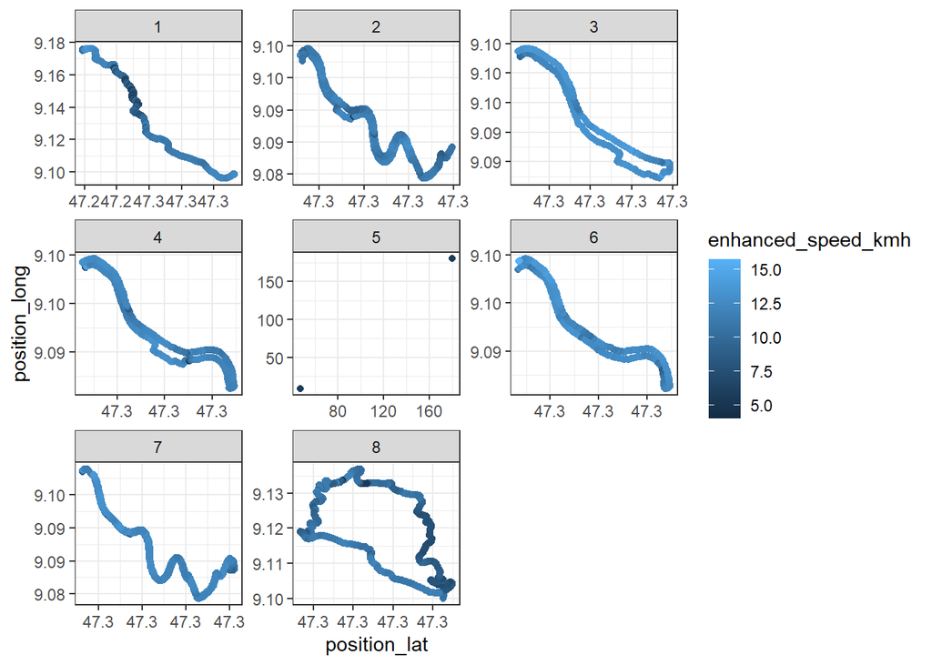

```r
# Visualisierung mit ggplot ohne Karte
library(tidyverse)
ggplot(filter(full, enhanced_speed_kmh > 4), aes (position_lat, position_long, col = enhanced_speed_kmh)) +
  geom_point() +
  facet_wrap(~activity_ID, scales = "free") +
  theme_bw()
```

Beim Track 5 scheint es noch ein Problem mit den Daten zu geben.

Leaflet ist interaktiv (m.E. sehr cool ;)) aber weniger einfach zu bearbeiten als ggplot oder ggmap (facets und einfärben von Datenpunkten etc.).

```r
# Visualiseriung mit leaflet() => Interaktiv, schwer zu bearbeiten
library(leaflet)

# Track 1
m1 <- full %>%
  filter(activity_ID ==1) %>%
  select(position_long, position_lat) %>%
  as.matrix() %>%
  leaflet(  ) %>%
  addTiles() %>%
  addPolylines( )
m1
```

[interactive chart not shown]

```r
# Track 2
m2 <- full %>%
  filter(activity_ID ==2) %>%
  select(position_long, position_lat) %>%
  as.matrix() %>%
  leaflet(  ) %>%
  addTiles() %>%
  addPolylines( )
m2
```

[interactive chart not shown]

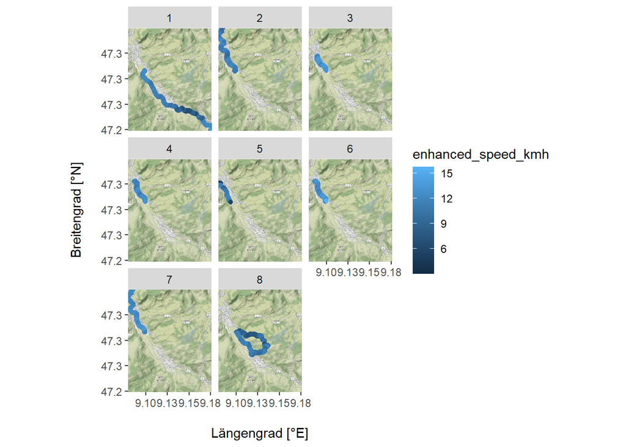

```r
# Visualiserung mit ggmap
track1_3 <- full %>%
  filter(activity_ID < 4)

library(ggmap)

myLocation <- c(min(track1_3$position_long), min(track1_3$position_lat),
                max(track1_3$position_long), max(track1_3$position_lat))  # Position definieren für Karten

myMap <- get_stamenmap(bbox=myLocation, maptype="terrain", crop=TRUE, zoom = 13)  # Kartenimport

ggmap(myMap) +
  geom_point(data = filter(full, enhanced_speed_kmh > 3),
             aes(position_long,position_lat, col = enhanced_speed_kmh)) +
  facet_wrap(~activity_ID) +
  labs(x = "\nLängengrad [°E]", y = "Breitengrad [°N]\n")
```

# Zusammenfassung pro Track

```r
zf <- full_sf %>%
  st_drop_geometry() %>%
  group_by(activity_ID) %>%
  summarise(
    date = date(timestamp[1]),
    distance = max(distance, na.rm = TRUE),
    time = as.numeric(difftime(max(timestamp), min(timestamp), units = "mins")),
    hightdiff_up = sum(hightdiff_up, na.rm = TRUE),
    hightdiff_down = sum(hightdiff_down, na.rm = TRUE),
    mean_pace = time / distance * 1000
    )
```

# Multimodel Inference

```r
if(!require(MuMIn)){install.packages("MuMIn")}
library(MuMIn)
library(gridExtra)
global.model <- lm(zf$time ~ 0 + zf$distance + zf$hightdiff_up + zf$hightdiff_down, data=zf)
options(na.action="na.fail")
allmodels <- dredge(global.model)
allmodels
```

```
## Global model call: lm(formula = zf$time ~ 0 + zf$distance + zf$hightdiff_up + zf$hightdiff_down,
##     data = zf)
## ---
## Model selection table
##    zf$dst zf$hgh_dwn zf$hgh_up df logLik AICc delta weight
## 6 0.00446               0.0781  3  -25.3 62.6  0.00  0.518
## 4 0.00429    -0.0767            3  -25.4 62.8  0.19  0.471
## 8 0.00434    -0.0369    0.0420  4  -24.9 71.1  8.54  0.007
## 2 0.00668                       2  -32.9 72.2  9.57  0.004
## 3            -0.1772            2  -35.9 78.3 15.67  0.000
## 5                       0.1878  2  -36.6 79.7 17.07  0.000
## 7            -0.1869   -0.0106  3  -35.9 83.9 21.26  0.000
## 1                               1  -44.6 91.9 29.32  0.000
## Models ranked by AICc(x)
```

```r
importance(allmodels)
```

```
##                      zf$distance zf$hightdiff_up zf$hightdiff_down
## Sum of weights:      1.00        0.52            0.48
## N containing models:    4           4               4
```

```r
avgmodel<-model.avg(get.models(dredge(global.model,rank="AICc"),subset=TRUE))
summary(avgmodel)
```

```
##
## Call:
## model.avg(object = get.models(dredge(global.model, rank = "AICc"),
##     subset = TRUE))
##
## Component model call:
## lm(formula = zf$time ~ <8 unique rhs>, data = zf)
##
## Component models:
##        df logLik AICc delta weight
## 13      3  -25.3 62.6  0.00   0.52
## 12      3  -25.4 62.8  0.19   0.47
## 123     4  -24.9 71.1  8.54   0.01
## 1       2  -32.9 72.2  9.57   0.00
## 2       2  -35.9 78.3 15.67   0.00
## 3       2  -36.6 79.7 17.07   0.00
## 23      3  -35.9 83.9 21.26   0.00
## (Null)  1  -44.6 91.9 29.32   0.00
##
## Term codes:
##       zf$distance zf$hightdiff_down   zf$hightdiff_up
##                 1                 2                 3
##
## Model-averaged coefficients:
## (full average)
##                    Estimate Std. Error Adjusted SE z value Pr(>|z|)
## zf$distance        0.004387   0.000508    0.000619    7.09   <2e-16 ***
## zf$hightdiff_up    0.040738   0.040315    0.041128    0.99     0.32
## zf$hightdiff_down -0.036412   0.039557    0.040317    0.90     0.37
##
## (conditional average)
##                    Estimate Std. Error Adjusted SE z value Pr(>|z|)
## zf$distance        0.004389   0.000502    0.000614    7.15  < 2e-16 ***
## zf$hightdiff_up    0.077603   0.015338    0.019008    4.08  4.4e-05 ***
## zf$hightdiff_down -0.076177   0.015632    0.019271    3.95  7.7e-05 ***
## ---
## Signif. codes:  0 '***' 0.001 '**' 0.01 '*' 0.05 '.' 0.1 ' ' 1
## Standard errors cannot be calculated because some component models do
##     not provide them
```

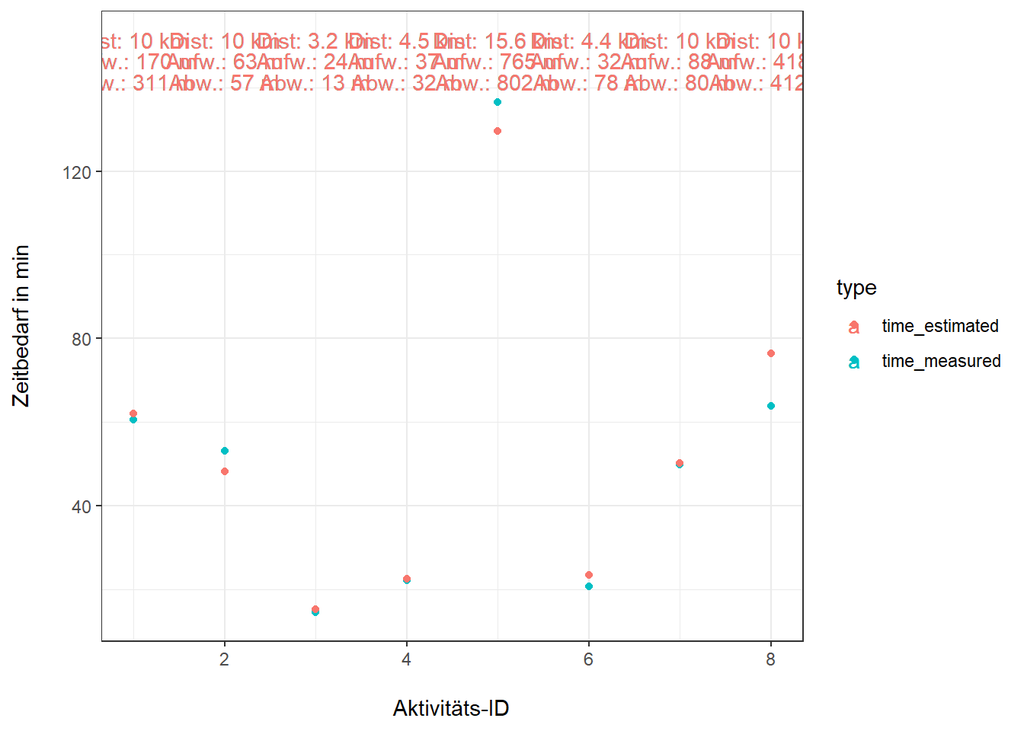

```r
# Komischerweise ist das "drittbeste Modell" einiges genauer als das beste Modell...
distance_param <- allmodels$`zf$distance`[3]
up_param <- allmodels$`zf$hightdiff_up`[3]
down_param <- allmodels$`zf$hightdiff_down`[3]

zf$time_estimated <- zf$distance *distance_param + zf$hightdiff_up * up_param + zf$hightdiff_down * down_param

zf %>%
  select(activity_ID, time_measured = time, time_estimated, distance, hightdiff_up, hightdiff_down) %>%
  gather(type, value, time_measured, time_estimated) %>%
  ggplot(aes(activity_ID, value, col = type)) +
  geom_point() +
  geom_text(aes(y = max(zf$time) + 15, label = paste("Dist:", round(distance/1000,1), "km"))) +
  geom_text(aes(y = max(zf$time) + 10, label = paste("Aufw.:", round(hightdiff_up,0), "m"))) +
  geom_text(aes(y = max(zf$time) + 5, label = paste("Abw.:", -round(hightdiff_down,0), "m"))) +
  theme_bw() +
  labs(x = "\nAktivitäts-ID", y = "Zeitbedarf in min\n")
```